# NYC Taxi Trip Duration Prediction

## Average speed per hour

Let's look at the average speed of NYC Taxi per hour.

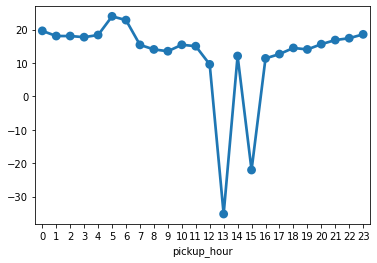

```python
group9 = data.groupby('pickup_hour').speed.mean()
sns.pointplot(group9.index, group9.values)
plt.show()
```

## Average speed per weekday

Let's visualize that on an average what is the speed of a taxi on any given weekday.

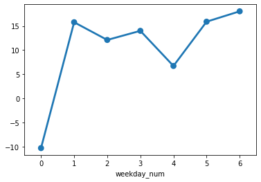

```python
group10 = data.groupby('weekday_num').speed.mean()
sns.pointplot(group10.index, group10.values)
plt.show()
```

## Passenger count per vendor

Let's try some different metric in the series i.e. passenger count. We will plot it agaist the vendor only because it will not be much helpful to plot it against hour, weekday or month like others as the passenger count should be a whole number and not a ratio.

we will take mean as the aggregate measure because we already did the outlier analysis on this metric. So our results woudn't be affected by some extreme values. Also if we take median than it will return only 1 because majorty of the trips have been taken by single passenger. Let's take a look about it's distribution.

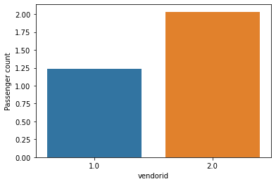

```python
group9 = data.groupby('vendorid').passenger_count.mean()
sns.barplot(group9.index, group9.values)
plt.ylabel('Passenger count')
plt.show()
```

Clear difference between the two operators for the average passenger count in all trips. It seems that vendor 2 trips generally consist of 2 passengers as compared to the vendor 1 with 1 passenger. Let's bifurcate it further.

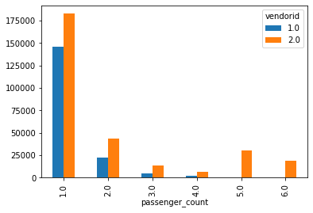

```python
data.groupby('passenger_count').vendorid.value_counts().reset_index(name='count').pivot("passenger_count","vendorid","count").plot(kind='bar')
plt.show()
```

### Interesting find

- It seems that most of the big cars are served by the Vendor 2 including minivans because other than passenger 1, vendor 2 has majority in serving more than 1 passenger count and that explains it greater share of the market.